# Impact of Regulations and Emissions

Exploratory data analysis

Quang-Vinh Do, Shaafici Ali, Thinh Hong, Youssef Makboul

2019-12-13

# Introduction and Objectives

The event of climate change has been a frequently discussed topic especially as of late. Although a considerable amount of people deny the magnitude of the event, there is an increased fear of the general repercussions of global warming. This fear has lead to a significant public pressure being applied to governments around the world demanding increased regulations in order to help prevent climate change. This has been especially the case in late 2019 where protesters in increasing numbers demonstrated to spread awareness as well as encourage a greater response from legislators. In addition, the protesters also criticize the adherence to international protocols, thereby questioning the effect of global treaties on government greenhouse gas(GHG) emission legislation.

There are several possible reasons explaining the government reluctance. It may be the case that there is a negative economic impact in the imposing of strict emission regulation as emission could be related to economy growth. It could also be the case that governments have been imposing regulations as a result of international accords. In addition, it is possible that regulations are simply not effective enough to invoke a reduction in emissions.

In this report, we will attempt to gain insight on the reasons causing government reluctance as well as the global effect of protocol. This involves the following objectives :

- Identify relationship between total GHG emissions and total economic growth
- Analyze the effect of international protocols on government emission legislation
- Identify relationship of total emission and particulate damage

# Emission Relationships

Part of the objectives involve identifying and potentially quantifying a relationship between the total greenhouse gas emissions and different variables. These variables include the environmental tax revenue as well as the total economic growth. It is important to note that the goal is not to identify a cause or effect but rather discover a common relationship between the variables for a number of countries.

## Definition of Variables

### Total Growth

The total growth of an economy was measured by its annual growth rate. Moreover, the annual growth rate represents the percentage change in total growth of the country’s GDP. In this context, “total” refers to the sum among all sectors. The data set used for this was sourced from the Organisation for Economic Co-operation and Development(OECD) which provided the total growth per sub-sector(activity) for a given country per year.[1]

### Total Emissions

The total emissions for a given country was measured by the sum of all of its greenhouse gas emissions for a given year. This includes the sum of the emissions of six gases classified as greenhouse gases. [2] The emission data was compiled over the course of over 20 years depending on the country.

### Environmental Tax Revenue

The environmental tax revenue is expressed as the percentage of the given country’s GDP. These tax revenues are generated from a variety of environmental domains. These domains include energy products, vehicle fuels, motor vehicles and transport services as well as other various other industries that are subject to an environmental tax. [3]

## Methodology

In order to gain insight on the relationship, a time series analysis is especially relevant. For each country, a separate time series for each of the respective variables was to be constructed. In every individual case, we wish to gain insight on whether one series’ changes is related to the other. We then evaluate the cross-correlations of the two time series using a cross correlation test with 95% confidence bounds.

To conduct a cross-correlation test, time series must be stationarized meaning that the mean and variance of the time series remains constant over time. To stationarized a given time series, differencing is necessary in which the change in value from one point is computed with a subsequent point in the time series. The stationarity of the time series is then confirmed by a ADF test as well as a KPSS test to test for trend-stationarity.

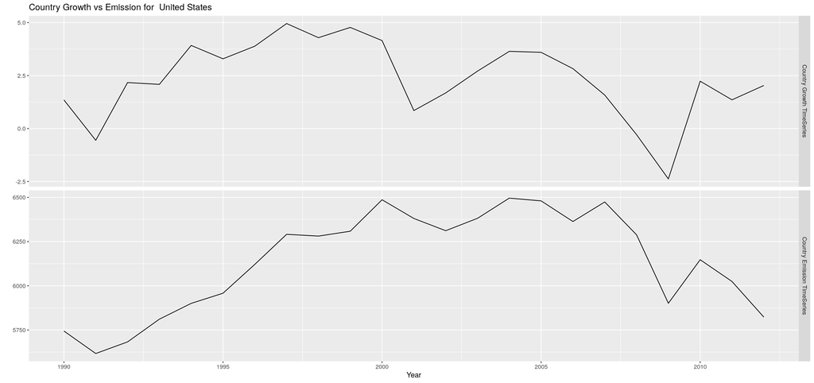

Raw Time Series

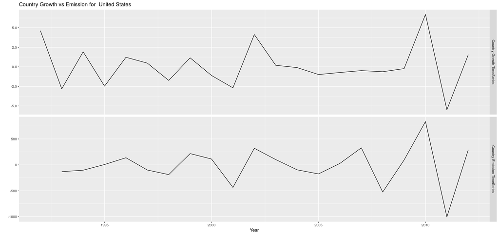

Differenced Time Series

This was accomplished by an automated procedure that would both stationarize ad hoc and compute the cross-correlations for two given-time series.

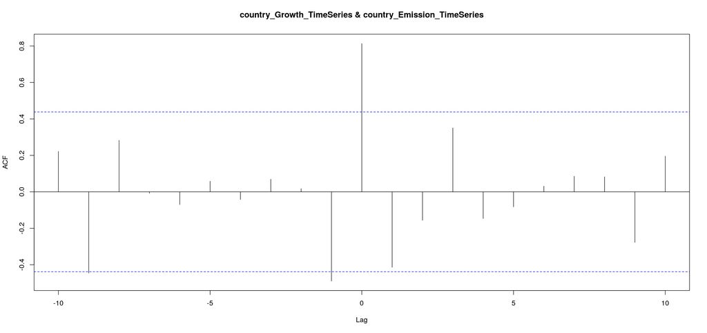

```
##
## Autocorrelations of series 'X', by lag
##
##    -10     -9     -8     -7     -6     -5     -4     -3     -2     -1
##  0.222 -0.446  0.282 -0.008 -0.070  0.058 -0.042  0.069  0.017 -0.489
##      0      1      2      3      4      5      6      7      8      9
##  0.813 -0.414 -0.156  0.351 -0.146 -0.082  0.031  0.085  0.082 -0.277
##     10
##  0.196
```

This process was to be completed for each country in data set that had sufficient year entries in order to construct the time series. In this case the cutoff was seven years as this would allow us to test for a reasonable amount of countries due to data set limitations. The statistically significant(= 0.05) country cross-correlations are then plotted together onto an amalgamated ACF plot that can then be analyzed.

## GHG Emissions and Economic Growth

### Hypothesis

It was hypothesized that there would be a positive relationship between emissions and total economy growth. In other words, a rise in green-house gas emissions would be correlated with a rise in economic growth. This is mainly because it is believed that emissions are generally associated with an increased industrial output and thus, intuitively, a rise in emissions would be followed by an increase in economic growth.

This would ideally be demonstrated by the emission time series serving as a positive lagging indicator for the economic growth time series. This is where the effect of increase in the emission time series transfers to the economic growth time series several periods(years) later.

### Results

The results were quite inconclusive but they did provide valuable insight. The resulting plot of cross-correlation was quite scattered with significant cross-correlations spread sparsely across the LAG axis. This can be observed in the plot below which represents the significant cross-correlations between economic growth and total emissions. This thus refuted our hypothesis as we expected cross-correlations to clearly tend to a negative lag with a positive cross-correlation.

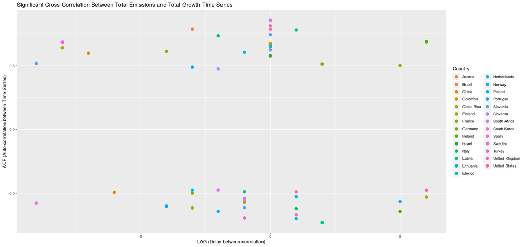

Interestingly, there appeared to be clusters in the 0, -1 and 1 lags. Notably, the largest cluster was located at the 0 lag and had a strongly positive auto-correlation. This would indicate that a rise in emissions is directly auto-correlated with an increase in economic growth in the same year. However, this cluster size is not significant enough to draw that conclusion.

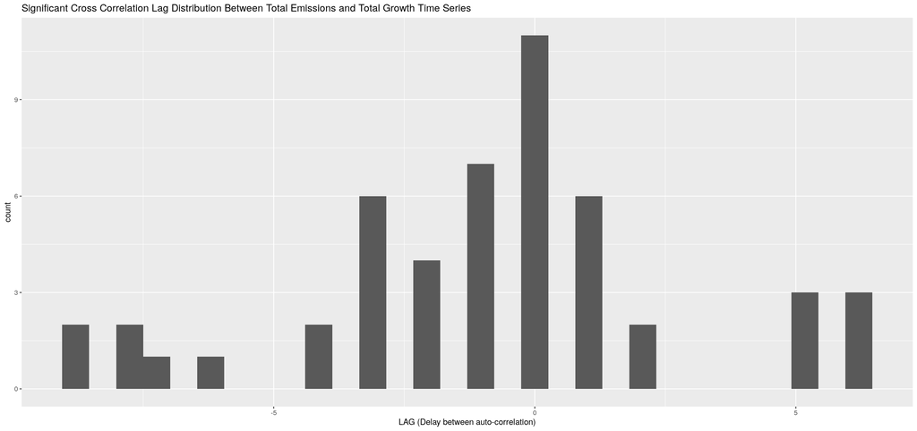

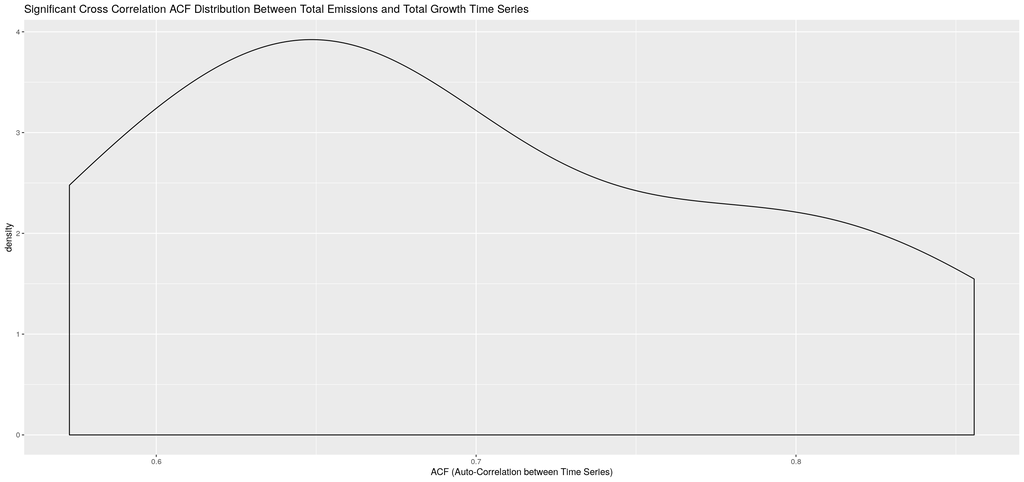

It was also difficult to draw a conclusion from the group of countries that were presented in this cluster. These countries included South Korea, Mexico, Netherlands, Slovakia, Turkey, United Kingdom, Slovenia, and the United States. It is possible that there is a shared economic attribute between these countries but it is not obvious.

Thus, the insight gained is that there is no evident cross-correlation between the total emission and economic growth for *all* countries. It could be the case that a significant cross correlation exists for countries with a specific economic attribute.

### Flaws and Further Exploration

A major flaw in our methodology is that the significance level was not adjusted for the number of tests being done for each individual country. This is especially the case for evaluating the significance of the cross-correlations. This may have perhaps lead to more conclusive results.

A further analysis could have been to classify countries by development level and then evaluate their respective emission/growth cross-correlations. This could have added more insight in terms of meaning of the different cross-correlation clusters at different lags.

## Environmental Tax Revenue and GHG Emissions

### Hypothesis

For the purpose of our analysis, it is inferred that the an increase in environmental tax revenue can indicate either an increased violation of emission regulations by industries or stringent regulations that are difficult to observe. This is a reasonable assumption as the environmental tax revenue represents the government revenue generated from environmentally related taxes.

This leads us to believe that the environmental tax revenue will serve as a lagging indicator with the emission time series. In other words, total emissions will react to the change of environmental tax will transfer to the total emissions years later. It also believed that this relationship will be negatively cross-correlated meaning that an increase in environmental tax revenue will lead to decreased total emissions. This is ultimately evaluating the effectiveness of regulations in the reduction of emissions.

### Results

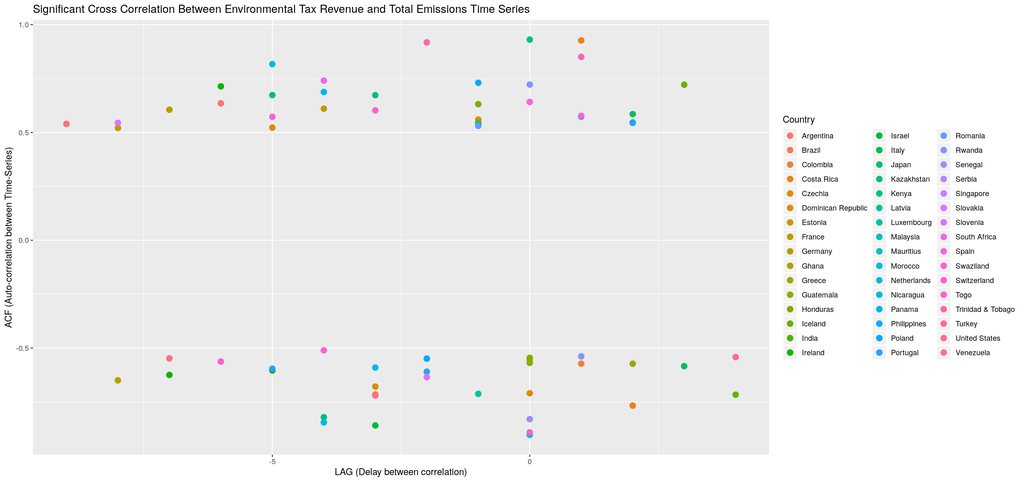

Upon inspection of the plot, the nature of the relationship is not easily determined as the cross-correlations do not have a clear positive or negative tendency. However, it can be inferred that the cross-correlations tend to have a negative lag as demonstrated by the lag density plot. Thus, it can be deduced that the environmental-tax revenue can serve as a lagging indicator for the total emissions of a given country. This can potentially indicate that emissions react to a change in environmental taxes.

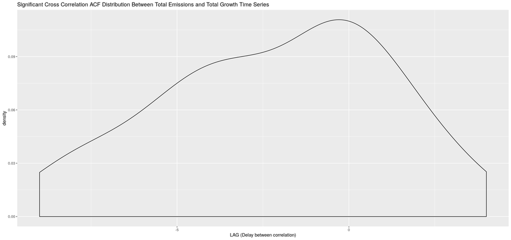

### Flaws and Further Exploration

Again, major flaw in our methodology is that the significance level was not adjusted for the number of tests being done for each individual country. Another potential flaw is that multiple variables affecting the environmental tax revenue were not considered. For instance, it could be the case that the environmental tax revenue was under reported in developing countries as there is likely to be bribes in place in exchange for tax breaks.

To remedy this potential inaccuracy, it would have been better to classify countries based on a corruption index to then analyse the emission reaction to environmental tax revenues.

Also, a further analysis could have been to classify countries by economy type as this can heavily affect the environmental tax revenues as well as the emissions. For instance, an heavily industrial economy will have different emission reactions as a relatively green economy since it may be more difficult to adjust emission levels since the emission are integral to the country’s output.

# Kyoto Protocol

Do regulations have any effect in reducing the amount of GHG emissions?

## Who are the biggest producers of GHG

We can start with a high level view and plot the ghg emissions per country to determine if certain areas have much higher amounts of emissions compared to others and to get a basic sense of which countries pollute the most.

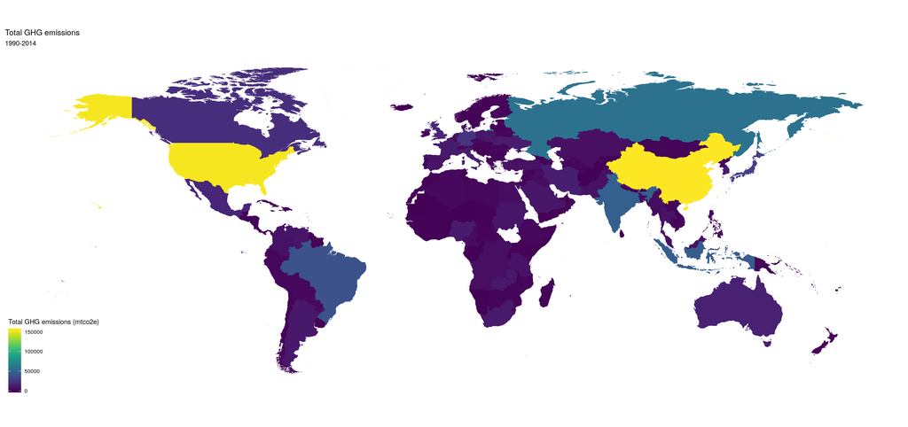

China and US have are by far the greatest GHG emitters. Next, we see Brazil, Russia, India, Japan, and others with noticeable amounts of GHG emissions. The other countries seem to have much lower amounts of emissions, however it looks like overall the more developed countries are emitting more.

We will limit our analysis to the countries with the highest total GHG emissions. We decided that it would be more insightful to analyze this subset of countries as they have the most impact on climate change. For our subset, we chose the top countries making up 80% of the global GHG emissions.

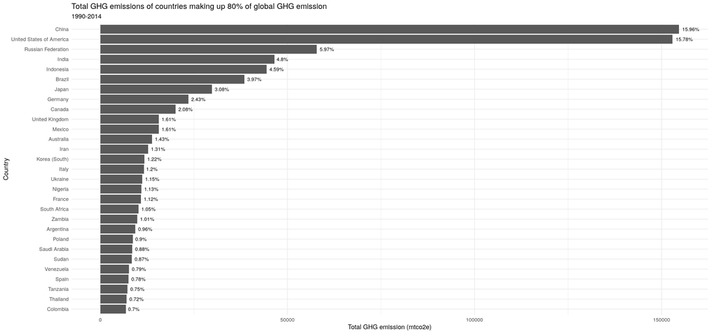

As shown in the above plot, there are 29 countries making up the top 80% of global emissions. US and China account for nearly 1/3 of global emissions at 31% while the other countries are more balanced in emissions.

## Did the Kyoto Protocol have an effect on GHG emissions?

Now that we have a subset of important countries to analyze, we want to determine if regulations have any impact on reducing GHG emissions. In particular, we will focus on the Kyoto Protocol which was an international treaty where parties are committed to reduce green house gas emissions. The Kyoto Protocol was effective as of February 16, 2005 and is currently ongoing for its second commitment period. We have manually checked on the United Nations Climate Change website that all 29 countries of interest were part of the protocol as of 2005 (as the data was not available for use).

Note that Canada withdrew in December 2012 however for this analysis we will examine the impact of the protocol being implemented as of 2005 and onward. As well, since the emission data is yearly we will assume that the emissions for year 2005 were under the Kyoto Protocol.

### Global effect

First let’s see how the Kyoto Protocol effected the global GHG emissions.

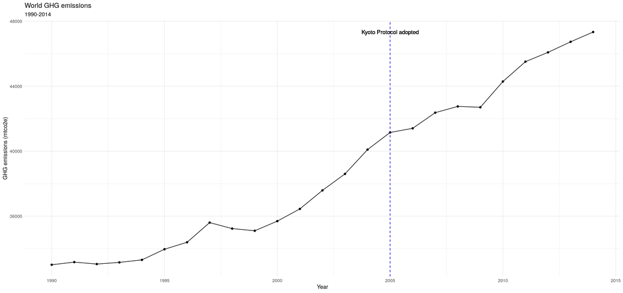

Just from eyeballing the plot it doesn’t look like the Kyoto Protocol had any impact on global GHG emissions as it seems to be climbing at the same rate as it was before the protocol. To confirm this, we will attempt to apply intervention analysis by modelling the time series as a regression with arima errors and determine if the coefficient is significant. The model is expressed as:

$y_t = \beta_0 + \beta_1 x_t + \eta_t$ where $\eta'_t = \phi_1 \eta'_{t-1} + \varepsilon_t$

$x_t$ is a vector of 0,1 where it’s 0 if is before the Kyoto Protocol effective date and 1 if after.

Note, this simply checks for constant changes to the mean value.

With this definition we get the following regression with arima errors model

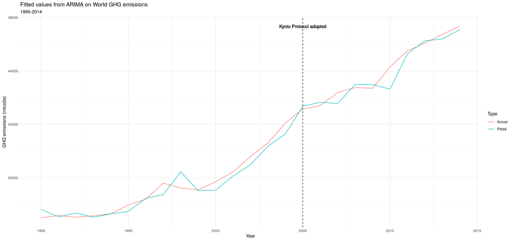

```
## Series: .
## Regression with ARIMA(2,0,0) errors
##
## Coefficients:
##          ar1      ar2  intercept      xreg
##       1.6464  -0.6582  39893.183  268.3900
## s.e.  0.1450   0.1486   5470.291  493.7005
##
## sigma^2 estimated as 400068:  log likelihood=-197.23
## AIC=404.46   AICc=407.62   BIC=410.55
##
## Training set error measures:
##                    ME     RMSE      MAE       MPE     MAPE      MASE
## Training set 165.3836 579.7044 431.8415 0.3898579 1.116764 0.6609637
##                    ACF1
## Training set -0.2412943
```

The best model found using the AIC is a regression with errors ARIMA(2,0,0) meaning it’s auto regressive only. It has fairly good performance metrics on the training set. Now we analyze residuals.

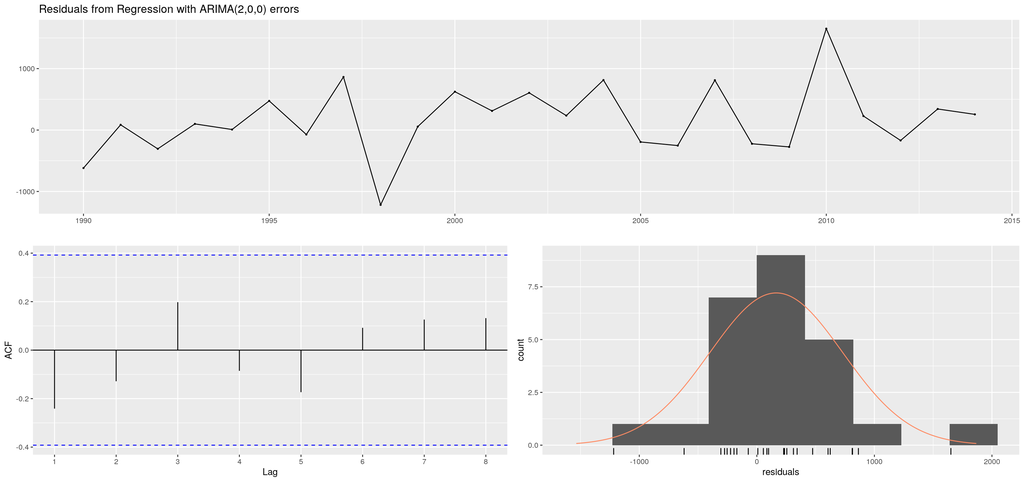

```
##
##  Ljung-Box test
##
## data:  Residuals from Regression with ARIMA(2,0,0) errors
## Q* = 5.4648, df = 3, p-value = 0.1408
##
## Model df: 4.   Total lags used: 7
```

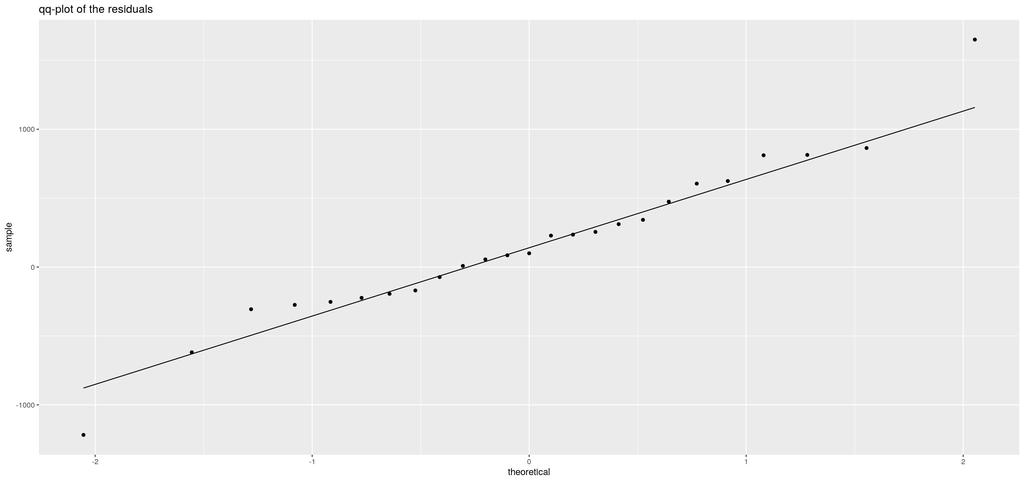

From the Ljung-Box test we get a p-value of 0.1408 which is fairly high so we can conclude that there’s no autocorrelation between the errors. As well, the residuals seem to follow a normal distribution from the qq-plot shown and also seems like random noise which indicates that the model has captured the proper patterns. Thus, the regression model with arima errors does a good job of modelling the time series.

```
##
## z test of coefficients:
##
##              Estimate  Std. Error z value  Pr(>|z|)
## ar1           1.64637     0.14503 11.3519 < 2.2e-16 ***
## ar2          -0.65822     0.14861 -4.4292 9.458e-06 ***
## intercept 39893.18297  5470.29099  7.2927 3.038e-13 ***
## xreg        268.38997   493.70053  0.5436    0.5867
## ---
## Signif. codes:  0 '***' 0.001 '**' 0.01 '*' 0.05 '.' 0.1 ' ' 1
```

From the output above of the p-values for the parameters it shows that xreg is not significant at all with a very high p-value of 0.5867. Thus we can conclude since the xreg parameter was not significant, then it does not add much information for the model and that the period after the Kyoto Protocol start date was not much different from before. Therefore the Kyoto Protocol didn’t have much impact on global GHG emissions!

### Per country effect

We suspect that this might not be true for certain countries. Some countries might have actually shown a significant change in their ghg emissions after the Kyoto Protocol. We will apply the same process as we did for World emissions but for our 29 countries of interest. Let’s start by viewing the ghg emissions over time for all countries.

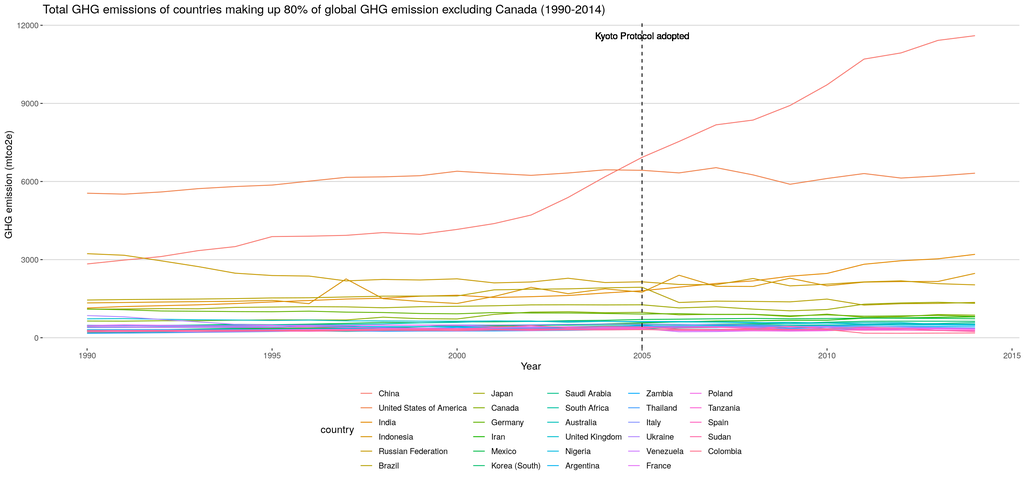

```
## [1] "Indonesia P-value: 6.0235477544006e-09"
```

From the output Indonesia is the only country that had a significant p-value, in this case of 6.02e-09 which is extremely significant. Let’s view its emissions overtime to see what was found.

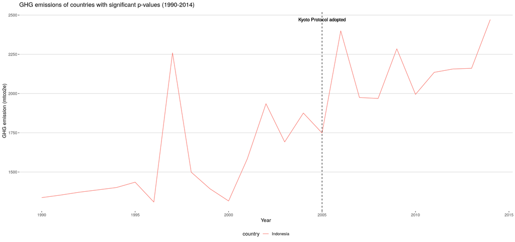

Since 2005, Indonesia has had a major increase in its GHG emissions and so the Kyoto Protocol doesn’t seem to have had an effect in reducing Indonesia’s GHG emissions. And neither did it have an effect for any of the other 28 countries either as they had non-significant p-values. Therefore, we can conclude that even at the per country level the Kyoto Protocol doesn’t seem to have had an impact in reducing GHG emissions. This confirms what we initially saw from the plot above as well.

## Kyoto Protocol effects on regulations

So even after the Kyoto Protocol was implemented there was no significant change in GHG emissions, but how active were countries in creating regulations relating to climate change after the Kyoto protocol was put into place?

We can attempt to answer this question by simply viewing the number of regulations total that were put into place in between 2005-2019 and 1991-2005. We can compare the number of regulations created between Kyoto Protocol start until present date with between 1991 to Kyoto Protocol start. This gives 14 years on either sides pre/post protocol to compare with. For this analysis, we will include all countries.

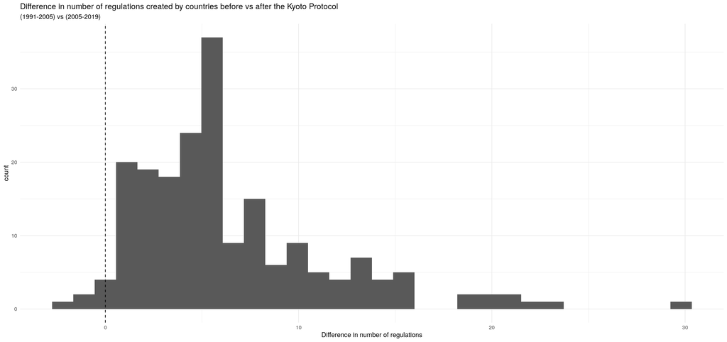

Looks like there have been many more regulations that have been created after 2005 than before 2005 for the same time ranges. Just to confirm we will do a paired t-test of difference of means

```
##
##  Paired t-test
##
## data:  regulations_compare$pre_kyoto and regulations_compare$post_kyoto
## t = -17.336, df = 197, p-value < 2.2e-16
## alternative hypothesis: true difference in means is less than 0
## 95 percent confidence interval:
##       -Inf -5.738715
## sample estimates:
## mean of the differences
##               -6.343434
```

As expected from just viewing the data, the p-value is extremely low of 2.2e-16 so we reject the null and we can say the means are significantly different from each other. This allows us to conclude that yes from 2005-2019 there have been more regulations than in 1991-2005 created by countries indicating that they are more active in climate change prevention, however we cannot necessarily conclude that it was due to the Kyoto Protocol. Note, we did not take into account the types or impacts of each individual regulation.

## Conclusion

Overall, no the Kyoto Protocol did not have any significant impact on the reduction of GHG emissions however countries have been more active in creating regulations concerning climate change since the Kyoto Protocol was initiated, whether it was due to the Kyoto Protocol or not. So even though countries have been more active, it doesn’t show in the GHG emissions. This could be due to either regulations aren’t strict enough or perhaps targeted parties, or industries aren’t following the regulations, or even that the regulations aren’t targeting the biggest causes of GHG emissions. However, regardless of the reason we can definitely conclude that there needs to be more effort in order to reduce GHG emissions and that prior efforts have had little effect.

## Assumptions/Comments

- A better method for Intervention Analysis could’ve been applied to compare the time series before and after the Kyoto Protocol adoption
- The exact GHG emissions used was total_ghg_emissions_including_land_use_change_and_forestry_mt_co_e as this included all emissions contributing to climate change
- Better method for handling multiple hypothesis testing could’ve been applied. In this case, even if we did not account for it none of the results would’ve changed
- For regulations per country, each regulation was counted equally and we did not take into account how one regulation has a larger impact than others in terms of what the regulation actually does
- 80% top country ghg emissions chosen was a bit arbitrary
- Not all countries were admitted to the Kyoto Protocol at the same time at 2005. Since the data was not available for use we made the assumption that they all joined at 2005.

## Suggestions for further work

Acquire monthly data to give more data points

View GHG emissions per capita instead. Population rises exponentially and has grown by a lot 6.5B in 2005 to 7.5B in 2019 so 1B change so of course we would expect that to cause greater emissions. We wouldn’t be surprised to see that the emissions per capita actually were affected after the Kyoto Protocol in 2005.

It would also be interesting to see the effects of regulations on a country and subsector view as we would expect certain industries to behave much more differently than others. The following plot shows for Canada the total GHG emissions per subsector and the points on the lines represent that a regulation was created on that year for that subsector. The second plot shows for Canada the energy subsector specifically along with actual names of regulations.

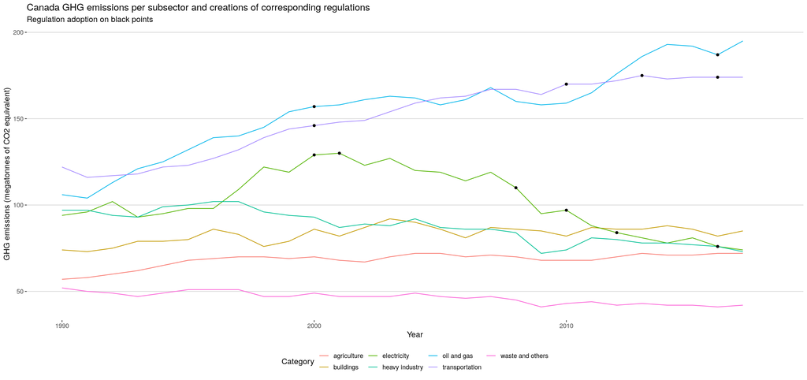

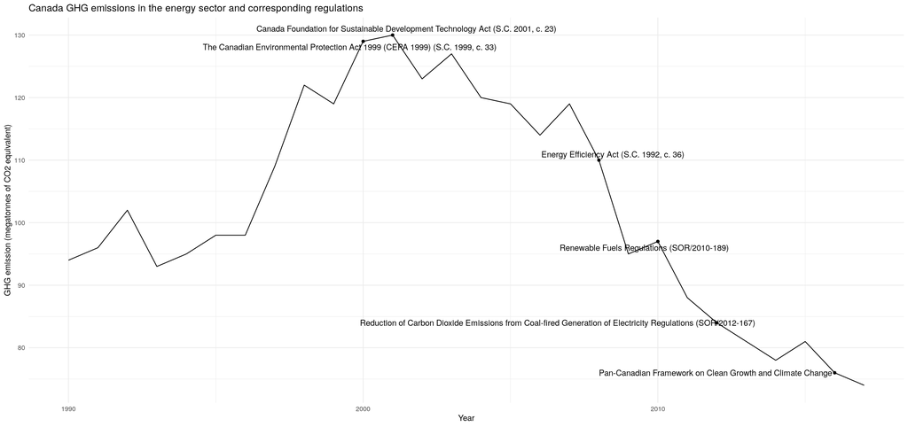

# References

1. **Total Growth Per Country:** https://data.oecd.org/natincome/value-added-by-activity.htm#indicator-chart
2. **Total Emission Per Country:** https://www.wri.org/resources/data-sets/cait-country-greenhouse-gas-emissions-data
3. **Environmental Tax Revenue:** https://data.oecd.org/envpolicy/environmental-tax.htm
4. https://otexts.com/fpp2/regarima.html